# New york Fordgobike 2019 data analysis

### Introduction

> A bicycle-sharing system, is a shared transport service in which bicycles are made available for shared use to individuals on a short term basis. Many bike share systems allow people to borrow a bike from a "dock" and return it at another dock belonging to the same system. [Wikipedia](https://en.wikipedia.org/wiki/Bicycle-sharing_system). In this report we will analyze a New York bike share dataset from January to december 2019, collected from [Bikeshare](https://s3.amazonaws.com/tripdata/index.html), it is a record of various features for every individual bike trips, additionally the New York weather dataset covering the same period are added from [(power.larc.nasa.gov)](https://power.larc.nasa.gov/data-access-viewer/) to complet the analysis taking into account climatic variation in order to study its impact on the bike trips.

```python
# import packages
import numpy as np
import pandas as pd
import matplotlib.pyplot as plt
import matplotlib.ticker as tick
from matplotlib.pyplot import subplots, show
%matplotlib inline
import seaborn as sns
import requests
from requests import get
import os
from os import path, getcwd, makedirs, listdir
from io import BytesIO
from zipfile import ZipFile
import datetime
import math
import calendar
import zipfile
import time
```

## Data wrangling

#### Data gathering

As first step we will automatically download the 2019 data from [Bikeshare](https://s3.amazonaws.com/tripdata/index.html) month by month, and concat all datasets in one dataframe. Next we will download manualy the weather data site from [(power.larc.nasa.gov)](https://power.larc.nasa.gov/data-access-viewer/) and read is as csv in this notebook finally we will extract the necessary columns for our analysis

```python
#set a wanted month to download in list
month_list=['201901','201902','201903','201904','201905','201906','201907','201908','201909','201910','201911',
            '201912']
```

```python
#Define a function to automatically download month datasets from link
def download_bike_data(month):
    url_start='https://s3.amazonaws.com/tripdata/JC-' #set repeatable link prefix
    url_end='-citibike-tripdata.csv.zip' #set repeatable link suffix
    URL= url_start+month+url_end # add month to set a complet link
    try:
        response=requests.get(URL) #set a request to get the url
    except:
        time.sleep(5) #set a sleep time if connection refused by the server
        response=requests.get(URL) # retry again
    with open('BIKEDATA'+month+'.zip', mode='wb') as file:
        file.write(response.content) #write the downloaded dataset in local storage
```

```python
#processing datasets download

start_time = time.time() #record start downloding time
for month in month_list: #use the download_bike_data function to download all months datasets in month_list
    download_bike_data(month)
    print('data-month {} downloded'.format(month)) #print check text to confirme
print("--- %s seconds ---" % (time.time() - start_time)) #show dowloading time
```

```
data-month 201901 downloded
data-month 201902 downloded
data-month 201903 downloded
data-month 201904 downloded
data-month 201905 downloded
data-month 201906 downloded
data-month 201907 downloded
data-month 201908 downloded
data-month 201909 downloded
data-month 201910 downloded
data-month 201911 downloded
data-month 201912 downloded
--- 117.38156151771545 seconds ---
```

```python
#concat all downloaded datasets in one dataframe
concat_df=pd.DataFrame() #set empty dataframe
cd=os.getcwd() #set the directory file
for i in range(len(month_list)):
    print(cd+'\BIKEDATA'+month_list[i]+'.zip')
    zf = zipfile.ZipFile(cd+'\BIKEDATA'+month_list[i]+'.zip') #target a dataset in zipped file
    month_df = pd.read_csv(zf.open('JC-'+month_list[i]+'-citibike-tripdata.csv')) #read a dataset as pandas dataframe
    concat_df=concat_df.append(month_df, ignore_index = True) # append a month dataframe to cancat dataframe
    print('Done') #check
```

```
C:\Users\Hp\BIKEDATA201901.zip
Done
C:\Users\Hp\BIKEDATA201902.zip
Done
C:\Users\Hp\BIKEDATA201903.zip
Done
C:\Users\Hp\BIKEDATA201904.zip
Done
C:\Users\Hp\BIKEDATA201905.zip
Done
C:\Users\Hp\BIKEDATA201906.zip
Done
C:\Users\Hp\BIKEDATA201907.zip
Done
C:\Users\Hp\BIKEDATA201908.zip
Done
C:\Users\Hp\BIKEDATA201909.zip
Done
C:\Users\Hp\BIKEDATA201910.zip
Done
C:\Users\Hp\BIKEDATA201911.zip
Done
C:\Users\Hp\BIKEDATA201912.zip
Done
```

```python
concat_df.shape
```

```
(404947, 15)
```

```python
#Read a weather dataset
df_weath=pd.read_csv('POWER_SinglePoint_Daily_20190101_20191231_040d76N_74d17W_f12334dc.csv', skiprows=27)
```

```python
#Extract a wanted columns
column_list=['YEAR', 'MO', 'DY', 'PRECTOT', 'RH2M', 'T2M', 'WS10M']
df_weath2=df_weath[column_list]
```

### Data assessing

```python
#visual assessing
concat_df.sample(5)
```

|  | tripduration | starttime | stoptime | start station id | start station name | start station latitude | start station longitude | end station id | end station name | end station latitude | end station longitude | bikeid | usertype | birth year | gender |
| --- | --- | --- | --- | --- | --- | --- | --- | --- | --- | --- | --- | --- | --- | --- | --- |
| 39038 | 216 | 2019-03-25 19:59:05.6670 | 2019-03-25 20:02:42.3020 | 3183 | Exchange Place | 40.716247 | -74.033459 | 3276 | Marin Light Rail | 40.714584 | -74.042817 | 29234 | Subscriber | 1980 | 1 |
| 331286 | 618 | 2019-10-14 09:07:41.8520 | 2019-10-14 09:18:00.5290 | 3268 | Lafayette Park | 40.713464 | -74.062859 | 3214 | Essex Light Rail | 40.712774 | -74.036486 | 29260 | Subscriber | 1986 | 1 |
| 307603 | 345 | 2019-09-27 23:27:59.2830 | 2019-09-27 23:33:45.2280 | 3194 | McGinley Square | 40.725340 | -74.067622 | 3193 | Lincoln Park | 40.724605 | -74.078406 | 29255 | Subscriber | 1962 | 1 |
| 260783 | 609 | 2019-08-30 14:32:13.9100 | 2019-08-30 14:42:23.6100 | 3195 | Sip Ave | 40.730897 | -74.063913 | 3280 | Astor Place | 40.719282 | -74.071262 | 26431 | Subscriber | 1986 | 1 |
| 31571 | 107 | 2019-02-14 09:00:34.8100 | 2019-02-14 09:02:22.2890 | 3267 | Morris Canal | 40.712419 | -74.038526 | 3214 | Essex Light Rail | 40.712774 | -74.036486 | 29262 | Subscriber | 1980 | 1 |

```python
concat_df.info()
```

```
<class 'pandas.core.frame.DataFrame'>
RangeIndex: 404947 entries, 0 to 404946
Data columns (total 15 columns):
 #   Column                   Non-Null Count   Dtype
---  ------                   --------------   -----
 0   tripduration             404947 non-null  int64
 1   starttime                404947 non-null  object
 2   stoptime                 404947 non-null  object
 3   start station id         404947 non-null  int64
 4   start station name       404947 non-null  object
 5   start station latitude   404947 non-null  float64
 6   start station longitude  404947 non-null  float64
 7   end station id           404947 non-null  int64
 8   end station name         404947 non-null  object
 9   end station latitude     404947 non-null  float64
 10  end station longitude    404947 non-null  float64
 11  bikeid                   404947 non-null  int64
 12  usertype                 404947 non-null  object
 13  birth year               404947 non-null  int64
 14  gender                   404947 non-null  int64
dtypes: float64(4), int64(6), object(5)
memory usage: 46.3+ MB
```

```python
concat_df[concat_df.duplicated()]
```

|  | tripduration | starttime | stoptime | start station id | start station name | start station latitude | start station longitude | end station id | end station name | end station latitude | end station longitude | bikeid | usertype | birth year | gender |
| --- | --- | --- | --- | --- | --- | --- | --- | --- | --- | --- | --- | --- | --- | --- | --- |

```python
concat_df.describe()
```

|  | tripduration | start station id | start station latitude | start station longitude | end station id | end station latitude | end station longitude | bikeid | birth year | gender |
| --- | --- | --- | --- | --- | --- | --- | --- | --- | --- | --- |
| count | 4.049470e+05 | 404947.000000 | 404947.000000 | 404947.000000 | 404947.000000 | 404947.000000 | 404947.000000 | 404947.000000 | 404947.000000 | 404947.000000 |
| mean | 7.258427e+02 | 3294.022391 | 40.722722 | -74.046333 | 3292.219142 | 40.722328 | -74.045792 | 28465.511998 | 1981.417524 | 1.162335 |
| std | 9.785237e+03 | 171.021930 | 0.007037 | 0.010871 | 180.886426 | 0.006885 | 0.010829 | 1654.373618 | 10.257440 | 0.516120 |
| min | 6.100000e+01 | 3183.000000 | 40.709651 | -74.083639 | 116.000000 | 40.695065 | -74.083639 | 14792.000000 | 1887.000000 | 0.000000 |
| 25% | 2.330000e+02 | 3195.000000 | 40.718355 | -74.050444 | 3192.000000 | 40.718355 | -74.050389 | 26286.000000 | 1975.000000 | 1.000000 |
| 50% | 3.450000e+02 | 3210.000000 | 40.721525 | -74.043845 | 3207.000000 | 40.721124 | -74.043117 | 29284.000000 | 1984.000000 | 1.000000 |
| 75% | 5.800000e+02 | 3276.000000 | 40.727224 | -74.038051 | 3276.000000 | 40.727224 | -74.038051 | 29536.000000 | 1989.000000 | 1.000000 |
| max | 2.566420e+06 | 3792.000000 | 40.748716 | -74.032108 | 3792.000000 | 40.814326 | -73.932077 | 41913.000000 | 2003.000000 | 2.000000 |

```python
concat_df[concat_df['birth year']<1929].shape
```

```
(197, 15)
```

```python
concat_df.tripduration.max()/3600
```

```
712.8944444444444
```

```python
concat_df[concat_df['tripduration']/3600>4].shape
```

```
(692, 15)
```

```python
#visual assessing
df_weath.sample(5)
```

|  | LAT | LON | YEAR | MO | DY | PRECTOT | QV2M | RH2M | T2M_RANGE | TS | ... | T2M_MIN | T2M | WS50M_RANGE | WS10M_RANGE | WS50M_MIN | WS10M_MIN | WS50M_MAX | WS10M_MAX | WS50M | WS10M |
| --- | --- | --- | --- | --- | --- | --- | --- | --- | --- | --- | --- | --- | --- | --- | --- | --- | --- | --- | --- | --- | --- |
| 20 | 40.75781 | -74.17159 | 2019 | 1 | 21 | 0.14 | 1.00 | 76.49 | 4.50 | -11.84 | ... | -16.00 | -13.73 | 3.04 | 2.28 | 9.95 | 6.51 | 12.99 | 8.79 | 11.66 | 7.97 |
| 138 | 40.75781 | -74.17159 | 2019 | 5 | 19 | 5.92 | 12.11 | 88.52 | 11.35 | 18.97 | ... | 13.27 | 18.94 | 3.97 | 2.75 | 3.86 | 2.35 | 7.83 | 5.09 | 5.98 | 3.60 |
| 171 | 40.75781 | -74.17159 | 2019 | 6 | 21 | 15.63 | 12.46 | 84.22 | 7.65 | 19.83 | ... | 15.56 | 20.00 | 5.74 | 3.39 | 2.86 | 1.67 | 8.60 | 5.06 | 6.37 | 3.46 |
| 345 | 40.75781 | -74.17159 | 2019 | 12 | 12 | 0.00 | 2.09 | 67.05 | 7.20 | -1.84 | ... | -5.37 | -2.42 | 6.81 | 3.73 | 0.24 | 0.19 | 7.04 | 3.91 | 3.95 | 2.28 |
| 360 | 40.75781 | -74.17159 | 2019 | 12 | 27 | 0.08 | 5.49 | 99.46 | 4.99 | 4.95 | ... | 3.47 | 5.35 | 1.96 | 0.60 | 4.26 | 2.42 | 6.22 | 3.02 | 5.37 | 2.70 |

5 rows × 23 columns

```python
df_weath.info()
```

```
<class 'pandas.core.frame.DataFrame'>
RangeIndex: 365 entries, 0 to 364
Data columns (total 23 columns):
 #   Column       Non-Null Count  Dtype
---  ------       --------------  -----
 0   LAT          365 non-null    float64
 1   LON          365 non-null    float64
 2   YEAR         365 non-null    int64
 3   MO           365 non-null    int64
 4   DY           365 non-null    int64
 5   PRECTOT      365 non-null    float64
 6   QV2M         365 non-null    float64
 7   RH2M         365 non-null    float64
 8   T2M_RANGE    365 non-null    float64
 9   TS           365 non-null    float64
 10  T2MDEW       365 non-null    float64
 11  T2MWET       365 non-null    float64
 12  T2M_MAX      365 non-null    float64
 13  T2M_MIN      365 non-null    float64
 14  T2M          365 non-null    float64
 15  WS50M_RANGE  365 non-null    float64
 16  WS10M_RANGE  365 non-null    float64
 17  WS50M_MIN    365 non-null    float64
 18  WS10M_MIN    365 non-null    float64
 19  WS50M_MAX    365 non-null    float64
 20  WS10M_MAX    365 non-null    float64
 21  WS50M        365 non-null    float64
 22  WS10M        365 non-null    float64
dtypes: float64(20), int64(3)
memory usage: 65.7 KB
```

```python
df_weath[df_weath.duplicated()]
```

|  | LAT | LON | YEAR | MO | DY | PRECTOT | QV2M | RH2M | T2M_RANGE | TS | ... | T2M_MIN | T2M | WS50M_RANGE | WS10M_RANGE | WS50M_MIN | WS10M_MIN | WS50M_MAX | WS10M_MAX | WS50M | WS10M |
| --- | --- | --- | --- | --- | --- | --- | --- | --- | --- | --- | --- | --- | --- | --- | --- | --- | --- | --- | --- | --- | --- |

0 rows × 23 columns

```python
df_weath.describe()
```

|  | LAT | LON | YEAR | MO | DY | PRECTOT | QV2M | RH2M | T2M_RANGE | TS | ... | T2M_MIN | T2M | WS50M_RANGE | WS10M_RANGE | WS50M_MIN | WS10M_MIN | WS50M_MAX | WS10M_MAX | WS50M | WS10M |
| --- | --- | --- | --- | --- | --- | --- | --- | --- | --- | --- | --- | --- | --- | --- | --- | --- | --- | --- | --- | --- | --- |
| count | 3.650000e+02 | 3.650000e+02 | 365.0 | 365.000000 | 365.000000 | 365.000000 | 365.000000 | 365.000000 | 365.000000 | 365.000000 | ... | 365.000000 | 365.000000 | 365.000000 | 365.000000 | 365.000000 | 365.000000 | 365.000000 | 365.000000 | 365.000000 | 365.000000 |
| mean | 4.075781e+01 | -7.417159e+01 | 2019.0 | 6.526027 | 15.720548 | 3.799507 | 7.752192 | 80.068137 | 8.967041 | 11.179534 | ... | 6.713918 | 11.093644 | 4.032411 | 2.457890 | 2.858740 | 1.678384 | 6.891452 | 4.136247 | 5.038767 | 2.962055 |
| std | 3.557590e-13 | 6.403663e-13 | 0.0 | 3.452584 | 8.808321 | 7.136680 | 4.563303 | 10.370158 | 2.803142 | 9.864490 | ... | 9.687221 | 9.993541 | 1.649766 | 1.189772 | 1.800403 | 1.026268 | 2.168894 | 1.606298 | 1.831028 | 1.212474 |
| min | 4.075781e+01 | -7.417159e+01 | 2019.0 | 1.000000 | 1.000000 | 0.000000 | 0.960000 | 53.000000 | 2.350000 | -12.140000 | ... | -17.980000 | -13.760000 | 0.980000 | 0.600000 | 0.050000 | 0.010000 | 2.710000 | 1.670000 | 1.960000 | 1.110000 |
| 25% | 4.075781e+01 | -7.417159e+01 | 2019.0 | 4.000000 | 8.000000 | 0.010000 | 3.760000 | 72.750000 | 7.020000 | 1.900000 | ... | -1.810000 | 2.110000 | 2.850000 | 1.610000 | 1.470000 | 0.930000 | 5.420000 | 2.990000 | 3.710000 | 2.080000 |
| 50% | 4.075781e+01 | -7.417159e+01 | 2019.0 | 7.000000 | 16.000000 | 0.340000 | 6.920000 | 79.650000 | 8.990000 | 12.230000 | ... | 8.150000 | 11.950000 | 3.760000 | 2.230000 | 2.670000 | 1.590000 | 6.340000 | 3.760000 | 4.640000 | 2.660000 |
| 75% | 4.075781e+01 | -7.417159e+01 | 2019.0 | 10.000000 | 23.000000 | 3.940000 | 11.380000 | 88.410000 | 10.710000 | 20.440000 | ... | 15.140000 | 20.390000 | 4.820000 | 2.970000 | 3.910000 | 2.200000 | 8.000000 | 5.060000 | 6.030000 | 3.500000 |
| max | 4.075781e+01 | -7.417159e+01 | 2019.0 | 12.000000 | 31.000000 | 41.780000 | 19.240000 | 100.000000 | 17.330000 | 27.580000 | ... | 24.290000 | 27.850000 | 10.880000 | 7.380000 | 9.950000 | 6.510000 | 15.080000 | 10.090000 | 13.130000 | 8.530000 |

8 rows × 23 columns

##### Assessing summary

Bike trip dataframe:

- `starttime` and `endtime` column are object instead of datetime
- `usertype` are object instead of cathegorical type
- `gender` are int instead of cathegorical type
- we need to generate a new column to calculate duration from `starttime` and `endtime` colums
- we need to use columns: `start station latitude`, `start station longitude`, `end station latitude`and `end station longitude` to estimate the traveled distance.
- we need also to calculate users age using `birth year` and `starttime` colums
- spaces are in columns names
- 197 records contain an abnormal birth date less than 1929
- Some records in `trip_duration` are not normal 712 hour!

Weather dataframe:

- There is lot of unecessery columns
- columns names are not significants
- all dataframes must be joined in one dataframe

### Data cleaning

##### Define:

Joining dataframes

##### Code:

```python
#Preper bike trip and weather dataframe to be joined

#convert a YEAR MO and DY columns to date
df_weath['date']=pd.to_datetime(df_weath.YEAR*10000+df_weath.MO*100+df_weath.DY,format='%Y%m%d')

#Convert starttime and stoptime columns to datetime type
concat_df.starttime=pd.to_datetime(concat_df.starttime)
concat_df.stoptime=pd.to_datetime(concat_df.stoptime)
#Extract a date from starttime column
concat_df['date']=concat_df.starttime.dt.date
```

```python
#Join weather dataframe to bike trip dataframe
df=concat_df.set_index('date').join(df_weath.set_index('date'))
df.reset_index(drop=True); #reset index
```

##### Test

```python
df.info()
```

```
<class 'pandas.core.frame.DataFrame'>
DatetimeIndex: 404947 entries, 2019-01-01 to 2019-12-31
Data columns (total 38 columns):
 #   Column                   Non-Null Count   Dtype
---  ------                   --------------   -----
 0   tripduration             404947 non-null  int64
 1   starttime                404947 non-null  datetime64[ns]
 2   stoptime                 404947 non-null  datetime64[ns]
 3   start station id         404947 non-null  int64
 4   start station name       404947 non-null  object
 5   start station latitude   404947 non-null  float64
 6   start station longitude  404947 non-null  float64
 7   end station id           404947 non-null  int64
 8   end station name         404947 non-null  object
 9   end station latitude     404947 non-null  float64
```

[output cut: 30 more lines]

##### Define:

Drop unecessery colums

Variables name definition from documentation:  
T2M_MAX: Maximum Temperature at 2 Meters (C)  
WS50M_RANGE: Wind Speed Range at 50 Meters (m/s)  
WS50M: Wind Speed at 50 Meters (m/s)  
WS10M_RANGE: Wind Speed Range at 10 Meters (m/s)  
QV2M: Specific Humidity at 2 Meters (g/kg)  
WS50M_MIN: Minimum Wind Speed at 50 Meters (m/s)  
PRECTOT: Precipitation (mm day-1)  
WS10M_MIN: Minimum Wind Speed at 10 Meters (m/s)  
T2M_RANGE: Temperature Range at 2 Meters (C)  
T2M_MIN: Minimum Temperature at 2 Meters (C)  
WS10M: Wind Speed at 10 Meters (m/s)  
WS10M_MAX: Maximum Wind Speed at 10 Meters (m/s)  
RH2M: Relative Humidity at 2 Meters (%)  
WS50M_MAX: Maximum Wind Speed at 50 Meters (m/s)  
T2M: Temperature at 2 Meters (C)

##### Code:

```python
#Drop unecessery colums
column_list=[ 'PRECTOT', 'RH2M', 'T2M', 'WS10M']
drop_columns=['LAT','LON','YEAR','MO','DY','T2M_MAX', 'WS50M_RANGE', 'WS50M', 'WS10M_RANGE', 'QV2M', 'WS50M_MIN',
             'WS10M_MIN', 'T2M_RANGE', 'T2M_MIN', 'WS10M_MAX', 'WS50M_MAX', 'TS', 'T2MDEW', 'T2MWET']
df.drop(drop_columns, axis='columns', inplace=True)
```

##### Test:

```python
df.info()
```

```
<class 'pandas.core.frame.DataFrame'>
DatetimeIndex: 404947 entries, 2019-01-01 to 2019-12-31
Data columns (total 19 columns):
 #   Column                   Non-Null Count   Dtype
---  ------                   --------------   -----
 0   tripduration             404947 non-null  int64
 1   starttime                404947 non-null  datetime64[ns]
 2   stoptime                 404947 non-null  datetime64[ns]
 3   start station id         404947 non-null  int64
 4   start station name       404947 non-null  object
 5   start station latitude   404947 non-null  float64
 6   start station longitude  404947 non-null  float64
 7   end station id           404947 non-null  int64
 8   end station name         404947 non-null  object
 9   end station latitude     404947 non-null  float64
 10  end station longitude    404947 non-null  float64
 11  bikeid                   404947 non-null  int64
 12  usertype                 404947 non-null  object
 13  birth year               404947 non-null  int64
 14  gender                   404947 non-null  int64
 15  PRECTOT                  404947 non-null  float64
 16  RH2M                     404947 non-null  float64
 17  T2M                      404947 non-null  float64
 18  WS10M                    404947 non-null  float64
dtypes: datetime64[ns](2), float64(8), int64(6), object(3)
memory usage: 61.8+ MB
```

##### Define:

Rename columns and replace spaces with underscore

##### Code:

```python
#Rename dataframe columns
df.rename(columns ={'tripduration': 'trip_duration', 'starttime': 'start_time',
                     'stoptime': 'stop_time', 'start station id':'start_id',
                     'start station name': 'start_name', 'start station latitude': 'start_latitude',
                    'start station longitude':'start_longitude', 'end station id': 'end_id',
                     'end station name': 'end_name', 'end station latitude': 'end_latitude',
                     'end station longitude': 'end_longitude', 'bikeid':'bike_id', 'usertype':'user_type',
                    'birth year':'birth_year', 'PRECTOT':'precipitation', 'RH2M':'humidity', 'T2M':'temperature',
                     'WS10M':'wind_speed' }, inplace = True)
df.reset_index(drop=True);
```

##### Test:

```python
df.info()
```

```
<class 'pandas.core.frame.DataFrame'>
DatetimeIndex: 404947 entries, 2019-01-01 to 2019-12-31
Data columns (total 19 columns):
 #   Column           Non-Null Count   Dtype
---  ------           --------------   -----
 0   trip_duration    404947 non-null  int64
 1   start_time       404947 non-null  datetime64[ns]
 2   stop_time        404947 non-null  datetime64[ns]
 3   start_id         404947 non-null  int64
 4   start_name       404947 non-null  object
 5   start_latitude   404947 non-null  float64
 6   start_longitude  404947 non-null  float64
 7   end_id           404947 non-null  int64
 8   end_name         404947 non-null  object
 9   end_latitude     404947 non-null  float64
 10  end_longitude    404947 non-null  float64
 11  bike_id          404947 non-null  int64
 12  user_type        404947 non-null  object
 13  birth_year       404947 non-null  int64
 14  gender           404947 non-null  int64
 15  precipitation    404947 non-null  float64
 16  humidity         404947 non-null  float64
 17  temperature      404947 non-null  float64
 18  wind_speed       404947 non-null  float64
dtypes: datetime64[ns](2), float64(8), int64(6), object(3)
memory usage: 61.8+ MB
```

##### Define:

Drop all records with birth days less than 1929 (90 years old)

##### Code:

```python
#Drop all rows exeeding 90 years in age column
df= df[df['birth_year']> 1929]
```

##### Test:

```python
df['birth_year'].min()
```

```
1940
```

##### Define:

Using columns: start station latitude, start station longitude, end station latitudeand end station longitude to estimate the traveled distance.

##### Code:

Use `haversine` formula to calculate the distance covered for each trip, this [Link](https://www.movable-type.co.uk/scripts/latlong.html) show the steps to calculate distance between Latitude/Longitude points:

```python
#define a function to calculate distance between start and end points by following the steps presented in the link above
def calculat_distance(lat1, lon1, lat2, lon2):
    R = 6371
    φ1 = lat1 * math.pi/180
    φ2 = lat2 * math.pi/180
    Δφ = (lat2-lat1) * math.pi/180
    Δλ = (lon2-lon1) * math.pi/180

    a = math.sin(Δφ/2) * math.sin(Δφ/2) +math.cos(φ1) * math.cos(φ2) * math.sin(Δλ/2) * math.sin(Δλ/2)

    c = 2 * math.atan2(math.sqrt(a), math.sqrt(1-a))

    d = R * c

    return d
```

```python
#Creat a new column 'distance' by applying 'calculat_distance' function using lambda
df['distance'] = df.apply(lambda x: calculat_distance(x['start_latitude'], x['start_longitude'],x['end_latitude'], x['end_longitude']), axis=1)
```

##### Test:

```python
df['distance'].describe()
```

```
count    404750.000000
mean          0.985648
std           0.650043
min           0.000000
25%           0.583658
50%           0.873851
75%           1.256998
max          14.026602
Name: distance, dtype: float64
```

##### Define:

using birth year and starttime columns to calculate users age

##### Code:

```python
#Calculate the age of users in new column
df['age']=df['start_time'].dt.year-df['birth_year']
```

##### Test:

```python
df['age'].describe()
```

```
count    404750.000000
mean         37.539083
std          10.068458
min          16.000000
25%          30.000000
50%          35.000000
75%          44.000000
max          79.000000
Name: age, dtype: float64
```

##### Define:

Creat a new colmun to convert the users gender to letters and drop the numeric gender column

##### Code:

```python
#Creat a new colmun to convert the users gender to letters
df['gender_cath']=df['gender'].apply(lambda x: 'male' if x == 1 else ('female' if x==2 else 'unknown'))
#Drop the numeric gender column
df.drop('gender',axis='columns', inplace=True)
```

##### Test:

```python
df['gender_cath'].value_counts()
```

```
male       286348
female      92137
unknown     26265
Name: gender_cath, dtype: int64
```

##### Define:

Create a column to define a user periods age

##### Code:

```python
periods=['Adolescence', 'young adult', 'middle-aged adults', 'old' ]
bins=[15,17,34,54,90]
df['periods_age']=pd.cut(x=df['age'], bins=bins, labels=periods, ordered=True )
```

##### Test:

```python
df['periods_age'].value_counts()
```

```
young adult           191577
middle-aged adults    183195
old                    29801
Adolescence              177
Name: periods_age, dtype: int64
```

##### Define:

Drop all trips with duration exceeding 4 hours.

##### Code:

```python
#drop trips with duration exceeds 4 hours
df=df[df['trip_duration']/3600<=4]
```

##### Test:

```python
df['trip_duration'].max()/3600
```

```
3.9994444444444444
```

##### Define:

convert `gender_cath` ans `user_type` columns to category

##### Code:

```python
df['gender_cath'].value_counts()
```

```
male       286103
female      92011
unknown     25944
Name: gender_cath, dtype: int64
```

```python
df['user_type'].value_counts()
```

```
Subscriber    361542
Customer       42516
Name: user_type, dtype: int64
```

```python
sedan_classes_gender=['male', 'female', 'unknown']
vclasses_gender=pd.api.types.CategoricalDtype(ordered=True, categories=sedan_classes_gender)
sedan_classes_type=['Subscriber', 'Customer']
vclasses_type=pd.api.types.CategoricalDtype(ordered=True, categories=sedan_classes_type)
df['gender_cath']=df['gender_cath'].astype(vclasses_gender);
df['user_type']=df['user_type'].astype(vclasses_type);
```

##### Test:

```python
df.info()
```

```
<class 'pandas.core.frame.DataFrame'>
DatetimeIndex: 404058 entries, 2019-01-01 to 2019-12-31
Data columns (total 22 columns):
 #   Column           Non-Null Count   Dtype
---  ------           --------------   -----
 0   trip_duration    404058 non-null  int64
 1   start_time       404058 non-null  datetime64[ns]
 2   stop_time        404058 non-null  datetime64[ns]
 3   start_id         404058 non-null  int64
 4   start_name       404058 non-null  object
 5   start_latitude   404058 non-null  float64
 6   start_longitude  404058 non-null  float64
 7   end_id           404058 non-null  int64
 8   end_name         404058 non-null  object
 9   end_latitude     404058 non-null  float64
 10  end_longitude    404058 non-null  float64
 11  bike_id          404058 non-null  int64
 12  user_type        404058 non-null  category
 13  birth_year       404058 non-null  int64
 14  precipitation    404058 non-null  float64
 15  humidity         404058 non-null  float64
 16  temperature      404058 non-null  float64
 17  wind_speed       404058 non-null  float64
 18  distance         404058 non-null  float64
 19  age              404058 non-null  int64
 20  gender_cath      404058 non-null  category
 21  periods_age      404058 non-null  category
dtypes: category(3), datetime64[ns](2), float64(9), int64(6), object(2)
memory usage: 62.8+ MB
```

```python
#save the final df version as csv
df.to_csv('NY_Bike_dataset_2019_clean.csv')
```

### What is/are the main feature(s) of interest in your dataset?

> I'm most interested in figuring out what is the most user characteristics are the best in predicting the trip duration, and how this characteristics are related with rental time period, also im intersted to study what feature among added weather features are the best in predicting the daily trip count and the total daily rent time.

### What features in the dataset do you think will help support your investigation into your feature(s) of interest?

> Trip duration, start/end time and user characteristics features (age, gender, type) will help us to drow conclusions, also the weather feautures will help us to find out how the daily trip count and daily total rent time varie accourding to the climate.

## Univariate Exploration of Data

```python
df=pd.read_csv('NY_Bike_dataset_2019_clean.csv')
```

Start looking at the distribution of the trip duration:

```python
style_list=plt.style.available
print(style_list)
```

```
['Solarize_Light2', '_classic_test_patch', 'bmh', 'classic', 'dark_background', 'fast', 'fivethirtyeight', 'ggplot', 'grayscale', 'seaborn', 'seaborn-bright', 'seaborn-colorblind', 'seaborn-dark', 'seaborn-dark-palette', 'seaborn-darkgrid', 'seaborn-deep', 'seaborn-muted', 'seaborn-notebook', 'seabo…
```

```python
plt.style.use(style_list[15])
```

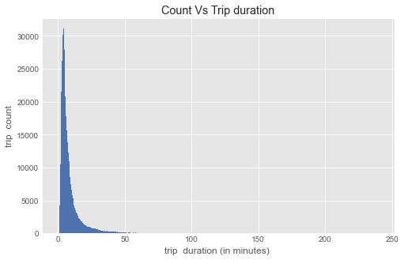

```python
# start with a standard-scaled plot
binsize = 0.5
bins = np.arange(0, df['trip_duration'].max()/60+binsize, binsize)
#ticks=[1,2,5,10,15,30,100, 400]
duration_min=df['trip_duration']/60
plt.figure(figsize=[8, 5])
plt.hist(duration_min , bins=bins)
plt.title('Count Vs Trip duration')
plt.xlabel('trip  duration (in minutes) ')
plt.ylabel('trip  count')
plt.show()
```

It seems that the trip duration distribution is limited to values less than 100 min, so we will modify our bins and scales to zoom in this distribution.

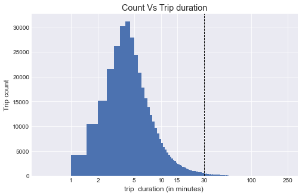

```python
# start with a standard-scaled plot
plt.style.use(style_list[14])
binsize = 0.5
bins = np.arange(0, df['trip_duration'].max()/60+binsize, binsize)
ticks=[1,2,5,10,15,30,100, 250]
duration_min=df['trip_duration']/60
plt.figure(figsize=[8, 5])
plt.hist(duration_min , bins=bins)
plt.xlabel('trip  duration (in minutes) ')
plt.ylabel('Trip count')
plt.title('Count Vs Trip duration')

plt.axvline(30, color='k', linestyle='dashed', linewidth=1)
plt.xscale('log')
plt.xticks(ticks, ticks)
plt.show()
```

```python
df['trip_duration'].mean()/60
```

```
9.290829988104017
```

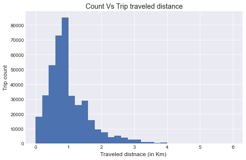

```python
# start with a standard-scaled plot
plt.style.use(style_list[14])
binsize = 0.2
bins = np.arange(0, 6+binsize, binsize)
#ticks=[1,2,5,10,15,30,100, 400]

plt.figure(figsize=[8, 5])
plt.hist(data=df, x='distance' , bins=bins)
plt.xlabel('Traveled distnace (in Km) ')
plt.ylabel('Trip count')
plt.title('Count Vs Trip traveled distance')

plt.show()
```

```python
#print the number of trips recordings 0 km in traveled distance
print('Number of trips with distance= 0: {}'
      .format(df[df['distance']==0]['distance'].count()))

#Calculate the trip duration mean for distance=0 records
print('Trip duration mean for distance=0 records: {}'
      .format(df[df['distance']==0]['trip_duration'].mean()/60))
```

```
Number of trips with distance= 0: 17206
Trip duration mean for distance=0 records: 32.327282149637725
```

It appears that the distance is right skweed with a large number (17206) of trips which register a distance = 0, calculating the mean duration we found 32 min, probabely this is because the distance calculation is based on the distance between the start and end station, if the starting station is the same as the end the traveled distance will be 0, which makes this metric irrelevant.

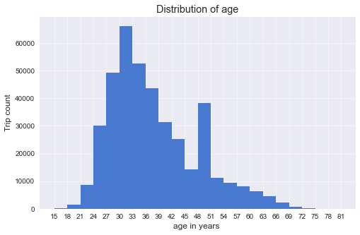

```python
# start with a standard-scaled plot
plt.style.use(style_list[14])
binsize = 3
bins = np.arange(15, 80+binsize, binsize)


plt.figure(figsize=[8, 5])
plt.hist(data=df, x='age' , bins=bins)
plt.xlabel('age in years ')
plt.ylabel('Trip count')
plt.title('Distribution of age')
plt.xticks(bins, bins);
plt.show()
```

```python
#print the number of users with 50 years old
df[df['age']==50].shape
```

```
(26207, 23)
```

```python
#print the number of users with 50 years old
df[df['age']==50]['gender_cath'].value_counts()
```

```
unknown    21921
male        3760
female       526
Name: gender_cath, dtype: int64
```

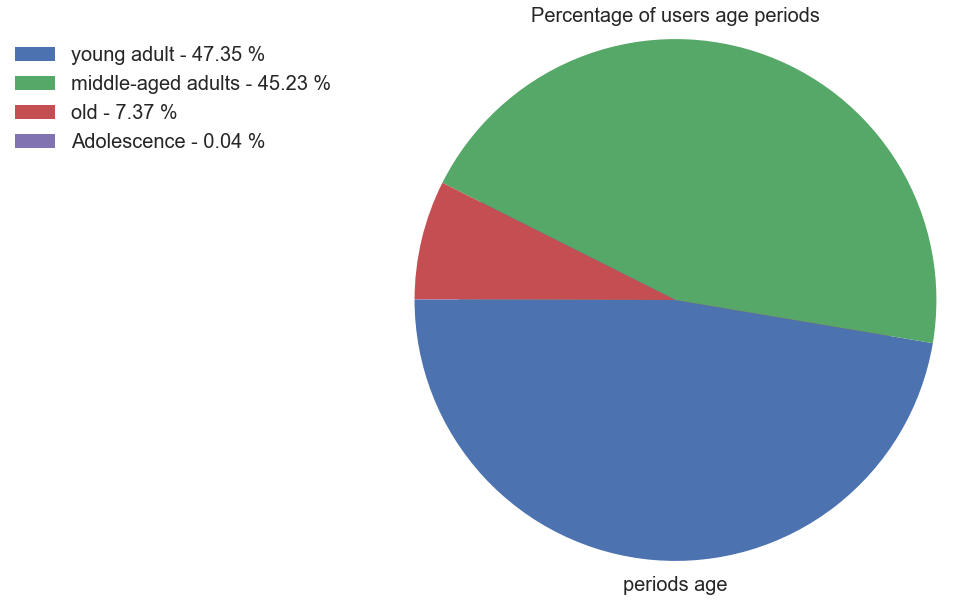

```python
plt.style.use(style_list[14])
df.periods_age.value_counts().plot(kind='pie', figsize=(10,10),fontsize =15, labels=None)

ax = plt.gca()
ax.set_ylabel('')
ax.set_xlabel('periods age', fontsize=20)
ax.set_title("Percentage of users age periods", fontsize=20)
plt.style.use("ggplot")

#Set a custom legend to put all necessary informations
x=df.periods_age.value_counts().index
y=df.periods_age.value_counts()
porcent = 100.*y/y.sum()
patches, texts = plt.pie(y, startangle=180, radius=1.2)
labels = ['{0} - {1:1.2f} %'.format(i,j) for i,j in zip(x, porcent)]
plt.legend(patches, labels, loc='best', bbox_to_anchor=(-0.1, 1.),
           fontsize=10, prop={'size': 20});
```

We find that the greatest percentage of trips are made by young adult (about 47.35%) followed by the middle aged adults (45.23%), on the other hand old age represent 7.37% and finnaly the adolescent are poorly observed with 0.04%.

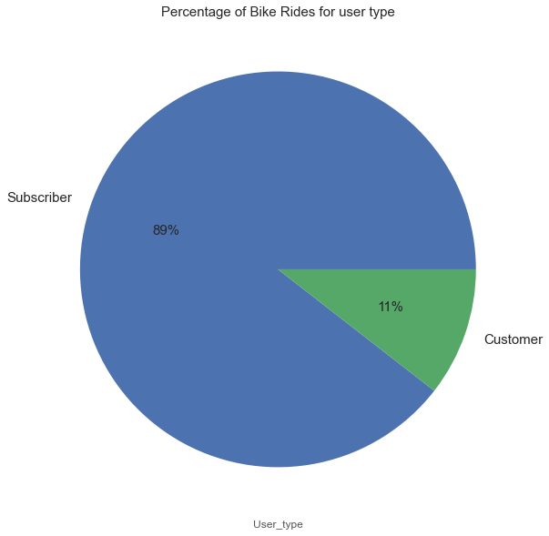

```python
plt.style.use(style_list[15])
df.user_type.value_counts().plot(kind='pie', figsize=(10,10),fontsize =15, autopct='%1.0f%%')
ax = plt.gca()
ax.set_ylabel('')
ax.set_xlabel('User_type')
ax.set_title("Percentage of Bike Rides for user type", fontsize=15);
```

Analyzing the percentage by user type, it is very visible that the subscriber dominates with a percentage of almost 90%.

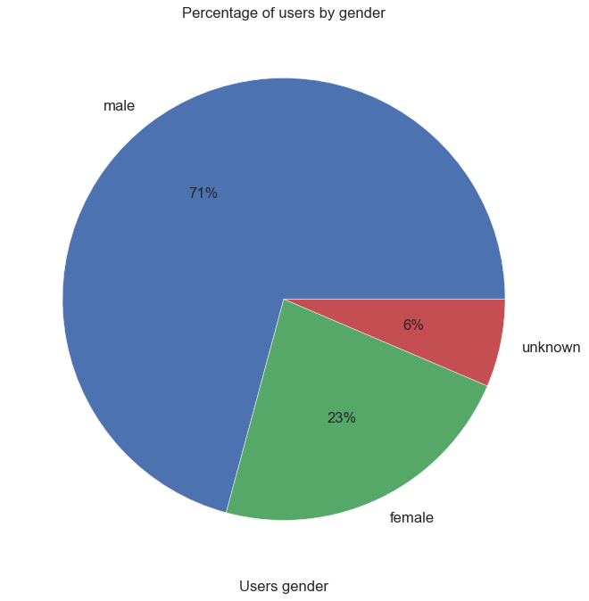

```python
plt.style.use(style_list[14])
df.gender_cath.value_counts().plot(kind='pie', figsize=(10,10),fontsize =15, autopct='%1.0f%%')
ax = plt.gca()
ax.set_ylabel('')
ax.set_xlabel('Users gender', fontsize=15)
ax.set_title("Percentage of users by gender", fontsize=15);
```

Males are the most frequently observed gender in the dataset with a percentage of 71%, in addition 23% are females and 6% are recorded as unknown

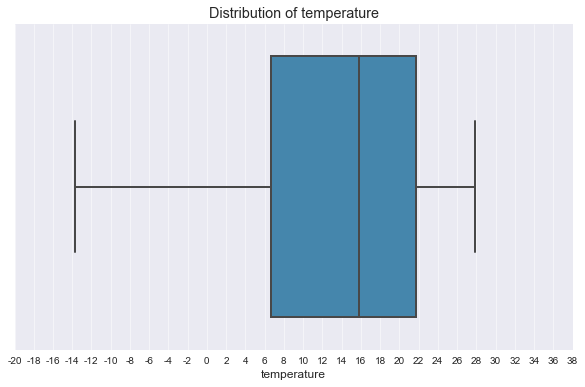

```python
plt.style.use(style_list[14])
ticks=np.arange(-20,40,2)
plt.figure(figsize=[10,6])
sns.boxplot(df['temperature'])
plt.xticks(ticks, ticks)
plt.title('Distribution of temperature');
```

The temperature distribution during trips is generally between 6 and 22 ° C.

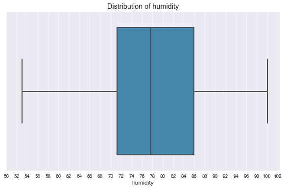

```python
plt.style.use(style_list[14])
ticks=np.arange(50,100+4,2)
plt.figure(figsize=[10,6])
sns.boxplot(df['humidity'])
plt.xticks(ticks, ticks)
plt.title('Distribution of humidity')
```

The relative humidity, is observed most of the time between 71 and 86%.

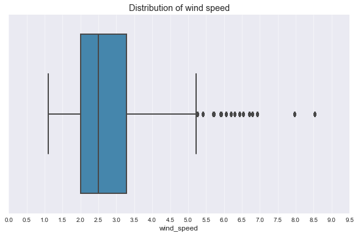

```python
plt.style.use(style_list[14])
ticks=np.arange(0,10,0.5)
plt.figure(figsize=[10,6])
sns.boxplot(df['wind_speed'])
plt.xticks(ticks, ticks)
plt.title('Distribution of wind speed');
```

The wind speed generally varies between 2 and 3.4 m/s, however a very few number of trips have been carried out in a climate where the wind speed exceeds 5 m/s.

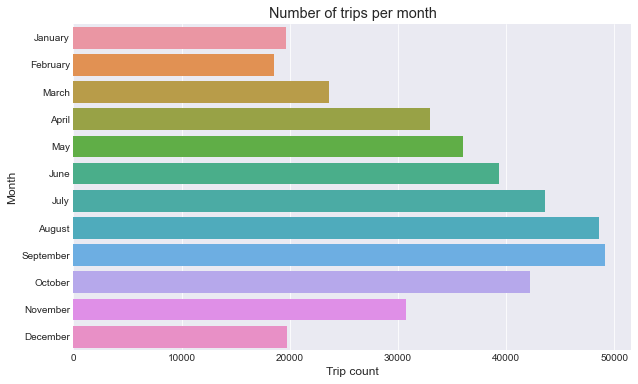

```python
plt.style.use(style_list[14])
df['start_time']=pd.to_datetime(df['start_time'])
moy=df.start_time.dt.strftime('%B')
plt.figure(figsize=[10, 6])
sns.countplot(y=moy)
plt.title('Number of trips per month')
plt.xlabel('Trip count')
plt.ylabel('Month')
```

We observe that the greatest number of trips recorded in August and September, on the other hand January, February and December are the months which recorded the lowest number of trips.

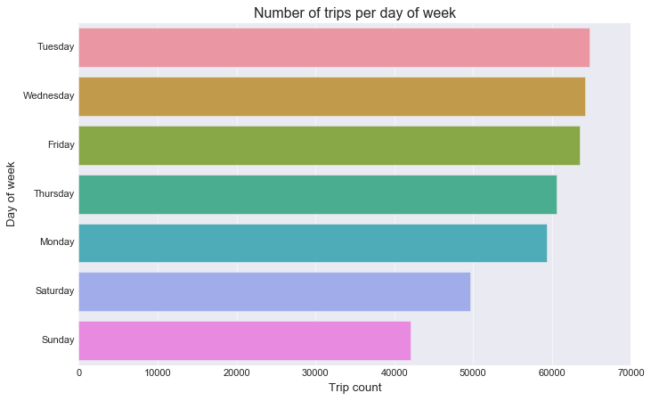

```python
plt.style.use(style_list[14])
dow=df.start_time.dt.strftime('%A')
plt.figure(figsize=[10, 6])
sns.countplot(y=dow, order=dow.value_counts().index)
plt.title('Number of trips per day of week')
plt.xlabel('Trip count')
plt.ylabel('Day of week')
```

Tuesday, Wednesday and friday are clearly the days of the week with the highest number of trips with a slight increase in favor of Tuesday, while Sunday and Saturday have the lowest number of trips.

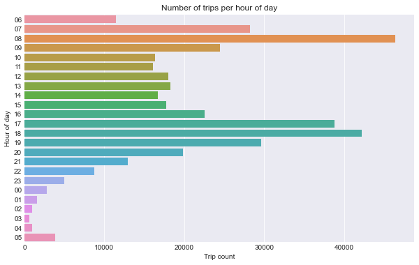

```python
plt.style.use(style_list[14])
hod=df.start_time.dt.strftime('%H')
hour_list=['06','07','08', '09','10', '11', '12', '13', '14', '15', '16',
           '17', '18', '19', '20', '21', '22', '23', '00', '01', '02', '03',
          '04', '05']
plt.figure(figsize=[10, 6])
sns.countplot(y=hod,order=hour_list)
plt.title('Number of trips per hour of day')
plt.xlabel('Trip count')
plt.ylabel('Hour of day')
```

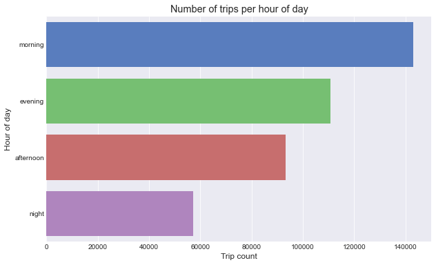

```python
plt.style.use(style_list[14])
#Creat a new column and cut data according to day parts

day_part=['night', 'morning', 'afternoon', 'evening', 'night']
bins=[-1,5,11,16,19,23]
df['day_part']=pd.cut(x=df.start_time.dt.strftime('%H').astype(int), bins=bins, labels=day_part, ordered=False)


#plot a count of trips for each day part
plt.figure(figsize=[10, 6])
sns.countplot(y=df['day_part'], order=df['day_part'].value_counts().index)
plt.title('Number of trips per hour of day')
plt.xlabel('Trip count')
plt.ylabel('Hour of day')
```

From these two graphs we see that most of the trips are recorded in the morning and evening especially between 07h am and 09h am, also between 16h pm and 20 pm, otherwise less trip count are observed at night.

### Of the features you investigated, were there any unusual distributions? Did you perform any operations on the data to tidy, adjust, or change the form of the data? If so, why did you do this?

> - the birth year distribution was unusual with 197 records containing an abnormal birth date less than 1929 (90 years old) which is not normal to use bike after this age, also a remarkable peak where the users age is exactly 50 years old (1969 on birth day) are observed, this may be due to an error in the registration system, we have filtered out outliers keeping only the ages under 90 years old to ensure the accuracy of dataset

### Bivariate Exploration

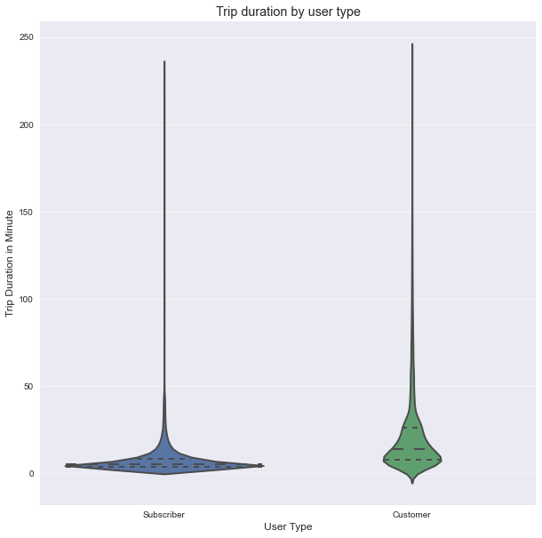

```python
plt.style.use(style_list[15])
plt.figure(figsize=[10, 10])
sns.violinplot(data=df, x='user_type', y=df['trip_duration']/60,inner='quartile');
plt.xlabel('User Type')
plt.ylabel('Trip Duration in Minute')
plt.title('Trip duration by user type');
```

According to the distribution of trip duration by user type, it seams that trip duration for customers is wider covering a wider duration interval with a larger median duration otherwise subscribers demonstrate a narrower duration distribution, this may explain a different usage for subscribers than for customers.

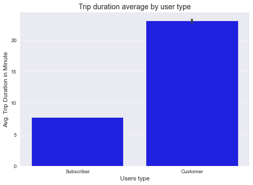

```python
plt.style.use(style_list[16])
sns.barplot(data=df, x='user_type', y=df['trip_duration']/60, color='blue');
plt.xlabel('Users type')
plt.ylabel('Avg. Trip Duration in Minute')
plt.title('Trip duration average by user type');
```

As a complement to the previous analysis we find that customers trip duration average are significantly exceeding the average trip duration for subscribers.

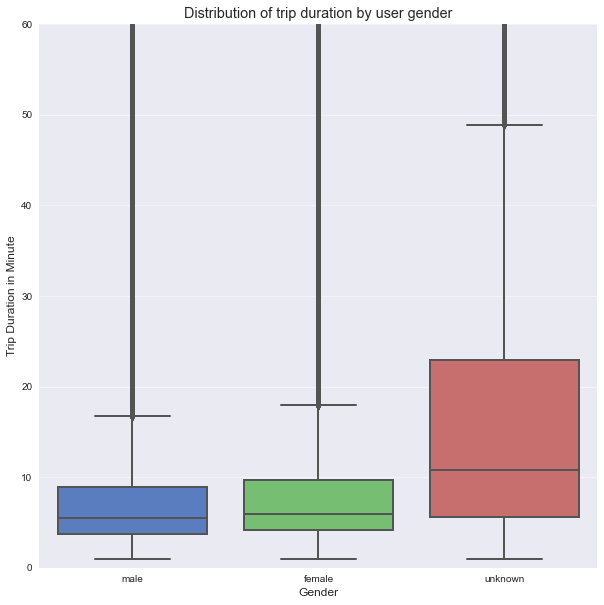

```python
plt.style.use(style_list[14])
plt.figure(figsize=[10, 10])
sns.boxplot(data=df, x='gender_cath', y=df['trip_duration']/60);
plt.xlabel('Gender');
plt.ylim(0,60) #set y axis limit to focus on interquartile range
plt.ylabel('Trip Duration in Minute')
plt.title('Distribution of trip duration by user gender');
```

Analyzing the trip duration distribution by gender, it turns out that the gender defined by 'unkown' tends to use bikes for longer time with a wider variation in trip duration, thus the duration of the trip for females is slightly longer than that of males.

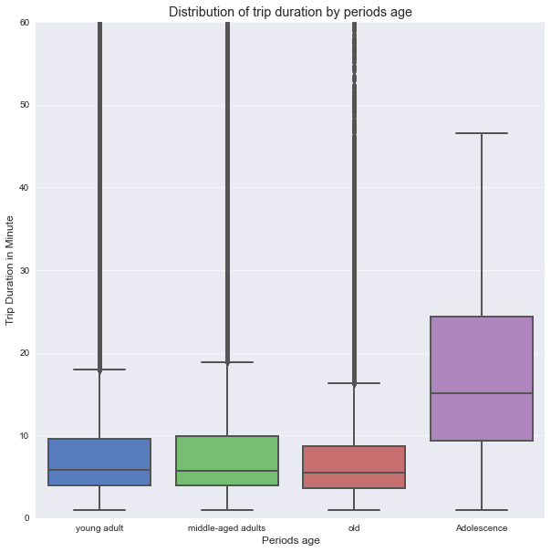

```python
plt.style.use(style_list[16])
plt.figure(figsize=[10, 10])
sns.boxplot(data=df, x='periods_age', y=df['trip_duration']/60);
plt.ylim(0,60) #set y axis limit to focus on interquartile range
plt.xlabel('Periods age');
plt.ylabel('Trip Duration in Minute')
plt.title('Distribution of trip duration by periods age');
```

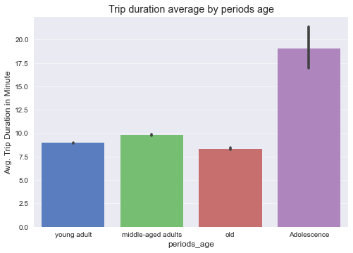

```python
plt.style.use(style_list[16])
sns.barplot(data=df, x='periods_age', y=df['trip_duration']/60);
plt.xlabel('periods_age');
plt.ylabel('Avg. Trip Duration in Minute')
plt.title('Trip duration average by periods age');
```

The distribution of trip duration by periods age shows that adolescents use bikes for a long time compared to other periods age, unlike old ages who show a shorter duration of use with a narrower distribution.

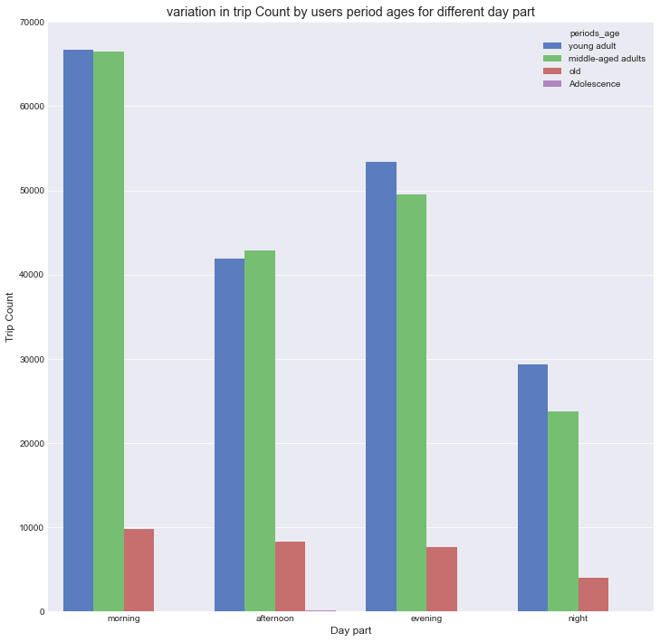

```python
plt.style.use(style_list[14])

order=['morning', 'afternoon', 'evening', 'night']
f=plt.figure(figsize=[12,12])
sns.countplot(data=df, x='day_part', hue='periods_age', order=order)
plt.xlabel('Day part');
plt.ylabel('Trip Count');
plt.title('variation in trip Count by users period ages for different day part');
```

We observe that the frequency of use for young adult and middle_aged adult is generally the same during morning and afternoon, unlike evening and night where the frequency of use of young adult remarkably exceeds middle_aged adult.

```python
#set a new data frame with daily trip count and weathe features average
df_count=df.groupby('date').agg(trip_count=('trip_duration', 'size'),
                                humidity_avg=('humidity', 'mean'),
                                temperature_avg=('temperature', 'mean'),
                                precipitation_avg=('precipitation', 'mean'),
                                wind_speed_avg=('wind_speed', 'mean'),
                                total_rent_time=('trip_duration', 'sum'),
                                total_traveled_distance=('distance', 'sum')
                               ).reset_index()
```

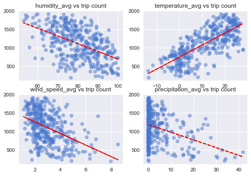

```python
#Scatter plot for trip count and every weather features
plt.style.use(style_list[17])


f, axes= plt.subplots(nrows = 2, ncols = 2)
f=plt.figure(figsize=[20,20])
f.tight_layout(pad=1)
features_list=['humidity_avg', 'temperature_avg', 'wind_speed_avg', 'precipitation_avg' ]
feature=0
for i in range (2):
    for j in range (2):
        x=df_count[features_list[feature]]
        y=df_count['trip_count']
        z = np.polyfit(x, y, 1)
        p = np.poly1d(z)
        axes[i,j].scatter(data=df_count, x=features_list[feature], y='trip_count', alpha=0.5)
        axes[i,j].set_title(features_list[feature]+ ' vs trip count')
        axes[i,j].plot(x,p(x),"r--")
        feature+=1
```

After ploting scatter plot of trip count of each weather feature, we observe that the best feature in predicting the trip count is the temperature and humidity but to a lesser degree.

[figure not shown]

```python
plt.style.use(style_list[16])
sns.barplot(data=df, x='gender_cath', y=df['age']);
plt.xlabel('periods_age');
#plt.ylim(20,45)
plt.ylabel('Avg. Trip Duration in Minute')
plt.title('Trip duration average by users gender');
```

The average age of the 'unknown' gender is remarkably larger, followed by males which slightly exceeds the average age of females.

[figure not shown]

```python
plt.style.use(style_list[16])
sns.barplot(data=df, x='day_part', y=df['age']);
plt.xlabel('day part');
plt.ylim(20,45)
plt.ylabel('Avg. Trip Duration in Minute')
plt.title('Trip duration average by day part ');
```

### Talk about some of the relationships you observed in this part of the investigation. How did the feature(s) of interest vary with other features in the dataset?

For trip duration:

- Customers trip duration is generally longer than subscribers
- 'Unkown' Gender trip duration tends to be much longer than male and femele
- The trip duration is more longer for adolescents compered to other periods age

For daily trip count:

- Temperature represents the strongest relation with daily trips count among the weather features followed by humidity but to a lesser degree

## Multivariate Exploration

```python
#group by date and gender and use agregat to calculate the daily trip count, the mean of weather features and age and the sum of trip duration and distance
df_gender=df.groupby(['date', 'gender_cath']).agg(trip_count=('trip_duration', 'size'),
                                humidity_avg=('humidity', 'mean'),
                                temperature_avg=('temperature', 'mean'),
                                precipitation_avg=('precipitation', 'mean'),
                                wind_speed_avg=('wind_speed', 'mean'),
                                total_rent_time=('trip_duration', 'sum'),
                                total_traveled_distance=('distance', 'sum'),
                                age_avg=('age', 'mean')
                               ).reset_index()

#pivot df_gender in order to have specific aggregated feature for each unique gender in columns and each unique date in rows
table_gender=pd.pivot_table(df_gender, index=['date'], columns=['gender_cath'],
                     values=['trip_count', 'total_rent_time', 'total_traveled_distance',
                            'humidity_avg', 'temperature_avg', 'precipitation_avg',
                            'wind_speed_avg', 'age_avg'],
                     aggfunc={'trip_count': np.mean,'total_rent_time':np.sum, 'total_traveled_distance':np.sum,
                            'humidity_avg':np.mean, 'temperature_avg':np.mean, 'precipitation_avg':np.mean,
                            'wind_speed_avg':np.mean,
                             'age_avg': np.mean}
                    ).reset_index()
#Drop level 0 columns index
table_gender.columns=table_gender.columns.droplevel(0)
#Set a list of new columns names
col_names=['date',
           'age_avg_f', 'age_avg_m', 'age_avg_u',
           'humidity','humidity_m','humidity_u',
           'precipitation', 'precipitation_m', 'precipitation_u',
           'temperature', 'temperature_m', 'temperature_u',
           'total_rent_time_f', 'total_rent_time_m', 'total_rent_time_u',
           'total_traveled_distance_f', 'total_traveled_distance_m', 'total_traveled_distance_u',
           'trip_count_f', 'trip_count_m', 'trip_count_u',
           'wind_speed', 'wind_speed_m', 'wind_speed_u']
#rename columns
table_gender.columns=col_names
#Drop duplicated columns
drop_columns=['humidity_m','humidity_u', 'precipitation_m', 'precipitation_u',
             'temperature_m', 'temperature_u', 'wind_speed_m', 'wind_speed_u' ]
table_gender.drop(drop_columns, axis='columns', inplace=True)
#Create a new columns to calculate gender ratio for each day
table_gender['female_ratio']=table_gender['trip_count_f']/(table_gender['trip_count_f']+table_gender['trip_count_m']+ table_gender['trip_count_u'])
table_gender['male_ratio']=table_gender['trip_count_m']/(table_gender['trip_count_f']+table_gender['trip_count_m']+ table_gender['trip_count_u'])
table_gender['unknown_ratio']=table_gender['trip_count_u']/(table_gender['trip_count_f']+table_gender['trip_count_m']+ table_gender['trip_count_u'])
table_gender.head()
```

|  | date | age_avg_f | age_avg_m | age_avg_u | humidity | precipitation | temperature | total_rent_time_f | total_rent_time_m | total_rent_time_u | total_traveled_distance_f | total_traveled_distance_m | total_traveled_distance_u | trip_count_f | trip_count_m | trip_count_u | wind_speed | female_ratio | male_ratio | unknown_ratio |
| --- | --- | --- | --- | --- | --- | --- | --- | --- | --- | --- | --- | --- | --- | --- | --- | --- | --- | --- | --- | --- |
| 0 | 2019-01-01 | 37.313253 | 37.587248 | 49.673469 | 91.37 | 1.64 | 7.48 | 50461.0 | 163124.0 | 108923.0 | 62.464163 | 244.654372 | 43.022046 | 83.0 | 298.0 | 49.0 | 5.41 | 0.193023 | 0.693023 | 0.113953 |
| 1 | 2019-01-02 | 37.365079 | 38.192691 | 48.611111 | 81.38 | 0.07 | 0.25 | 70945.0 | 234835.0 | 31789.0 | 163.590882 | 570.564739 | 28.152072 | 189.0 | 602.0 | 36.0 | 2.32 | 0.228537 | 0.727932 | 0.043531 |
| 2 | 2019-01-03 | 36.372881 | 38.334835 | 47.000000 | 89.86 | 0.29 | 2.20 | 71754.0 | 261402.0 | 6800.0 | 162.743538 | 648.940202 | 8.107255 | 177.0 | 666.0 | 16.0 | 3.04 | 0.206054 | 0.775320 | 0.018626 |
| 3 | 2019-01-04 | 36.854054 | 37.856094 | 46.121212 | 94.72 | 0.67 | 1.51 | 76057.0 | 260496.0 | 28991.0 | 175.908260 | 619.175897 | 30.985349 | 185.0 | 681.0 | 33.0 | 2.84 | 0.205784 | 0.757508 | 0.036707 |
| 4 | 2019-01-05 | 35.702381 | 37.571429 | 42.000000 | 97.01 | 19.88 | 4.05 | 31423.0 | 85288.0 | 11477.0 | 79.507143 | 212.639560 | 11.297539 | 84.0 | 210.0 | 14.0 | 3.90 | 0.272727 | 0.681818 | 0.045455 |

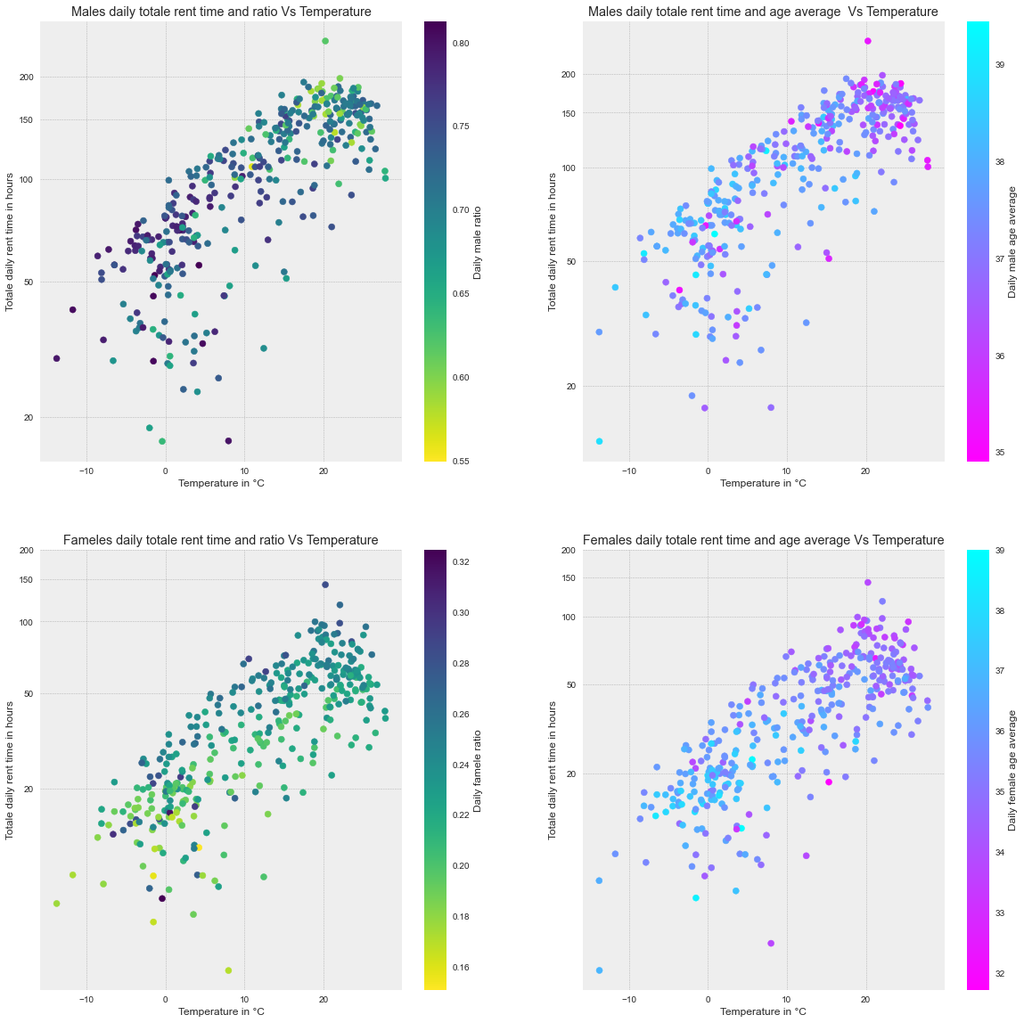

```python
plt.style.use(style_list[2])

ticks=[20,50,100,150, 200]

fig, ax = subplots(2,2, figsize=(20,20))

#Plotting Males daily totale rent time and ratio Vs Temperature
male_plt=ax[0,0].scatter( c=table_gender['male_ratio'], x=table_gender['temperature'], y=table_gender['total_rent_time_m']/3600, cmap='viridis_r')
ax[0,0].set_ylabel("Totale daily rent time in hours")
ax[0,0].set_title("Males daily totale rent time and ratio Vs Temperature")
ax[0,0].set_xlabel("Temperature in °C")
ax[0,0].set_yscale('log')
ax[0,0].set_yticks(ticks)
ax[0,0].set_yticklabels(ticks)
cbar=fig.colorbar(male_plt, ax=ax[0,0])
cbar.set_label('Daily male ratio', rotation=90)


#Plotting Males daily totale rent time and age average  Vs Temperature
male_plt=ax[0,1].scatter( c=table_gender['age_avg_m'], x=table_gender['temperature'], y=table_gender['total_rent_time_m']/3600, cmap='cool_r')
ax[0,1].set_ylabel("Totale daily rent time in hours")
ax[0,1].set_title("Males daily totale rent time and age average  Vs Temperature")
ax[0,1].set_xlabel("Temperature in °C")
ax[0,1].set_yscale('log')
ax[0,1].set_yticks(ticks)
ax[0,1].set_yticklabels(ticks)
cbar=fig.colorbar(male_plt, ax=ax[0,1])
cbar.set_label('Daily male age average', rotation=90)

#Plotting Fameles daily totale rent time and ratio Vs Temperature
female_plt=ax[1,0].scatter( c=table_gender['female_ratio'], x=table_gender['temperature'], y=table_gender['total_rent_time_f']/3600, cmap='viridis_r')
ax[1,0].set_ylabel("Totale daily rent time in hours")
ax[1,0].set_title("Fameles daily totale rent time and ratio Vs Temperature")
ax[1,0].set_xlabel("Temperature in °C")
ax[1,0].set_yscale('log')
ax[1,0].set_yticks(ticks)
ax[1,0].set_yticklabels(ticks)
cbar=fig.colorbar(female_plt, ax=ax[1,0])
cbar.set_label('Daily famele ratio', rotation=90)

#Plotting Females daily totale rent time and age average Vs Temperature
female_plt=ax[1,1].scatter( c=table_gender['age_avg_f'], x=table_gender['temperature'], y=table_gender['total_rent_time_f']/3600, cmap='cool_r')
ax[1,1].set_ylabel("Totale daily rent time in hours")
ax[1,1].set_title("Females daily totale rent time and age average Vs Temperature")
ax[1,1].set_xlabel("Temperature in °C")
ax[1,1].set_yscale('log')
ax[1,1].set_yticks(ticks)
ax[1,1].set_yticklabels(ticks)
cbar=fig.colorbar(female_plt, ax=ax[1,1])
cbar.set_label('Daily female age average', rotation=90)



show()
```

From these plots we see that:

- Total daily rent time is strongly related to temperature.
- the relationship between temperature and total daily rent time is positive, the more the temperature increases the more the total daily rent time increases in parallel.
- The ratio of females is significantly related to temperature the more the temperature increases the more the ratio of females increases in parallel.
- For both male and female the more the temperature the more the average age of the users decreases.

```python
#group by date and user_type and use agregat to calculate the daily trip count, the mean of weather features and age and the sum of trip duration and distance
df_type=df.groupby(['date', 'user_type']).agg(trip_count=('trip_duration', 'size'),
                                humidity_avg=('humidity', 'mean'),
                                temperature_avg=('temperature', 'mean'),
                                precipitation_avg=('precipitation', 'mean'),
                                wind_speed_avg=('wind_speed', 'mean'),
                                total_rent_time=('trip_duration', 'sum'),
                                total_traveled_distance=('distance', 'sum'),
                                age_avg=('age', 'mean')
                               ).reset_index()

#pivot df_type in order to have specific aggregated feature for each unique user type in columns and each unique date in rows
table_type=pd.pivot_table(df_type, index=['date'], columns=['user_type'],
                     values=['trip_count', 'total_rent_time', 'total_traveled_distance',
                            'humidity_avg', 'temperature_avg', 'precipitation_avg',
                            'wind_speed_avg', 'age_avg'],
                     aggfunc={'trip_count': np.mean,'total_rent_time':np.sum, 'total_traveled_distance':np.sum,
                            'humidity_avg':np.mean, 'temperature_avg':np.mean, 'precipitation_avg':np.mean,
                            'wind_speed_avg':np.mean,
                             'age_avg': np.mean}
                    ).reset_index()
#Drop level 0 columns index
table_type.columns=table_type.columns.droplevel(0)
#Set a list of new columns names
col_names=['date',
'age_avg_c', 'age_avg_s',
'humidity','humidity_s',
'precipitation', 'precipitation_s',
'temperature', 'temperature_s',
'total_rent_time_c', 'total_rent_time_s',
'total_traveled_distance_c', 'total_traveled_distance_s',
'trip_count_c', 'trip_count_s',
'wind_speed', 'wind_speed_s']
#rename columns
table_type.columns=col_names

#Drop duplicated columns
drop_columns=['humidity_s', 'precipitation_s', 'temperature_s', 'wind_speed_s' ]
table_type.drop(drop_columns, axis='columns', inplace=True)

#Create a new columns to calculate gender ratio for each day
table_type['custumer_ratio']=table_type['trip_count_c']/(table_type['trip_count_c']+table_type['trip_count_s'])
table_type['subscriber_ratio']=table_type['trip_count_s']/(table_type['trip_count_c']+table_type['trip_count_s'])


table_type.head()
```

|  | date | age_avg_c | age_avg_s | humidity | precipitation | temperature | total_rent_time_c | total_rent_time_s | total_traveled_distance_c | total_traveled_distance_s | trip_count_c | trip_count_s | wind_speed | custumer_ratio | subscriber_ratio |
| --- | --- | --- | --- | --- | --- | --- | --- | --- | --- | --- | --- | --- | --- | --- | --- |
| 0 | 2019-01-01 | 43.106061 | 38.151099 | 91.37 | 1.64 | 7.48 | 153666 | 168842 | 59.193626 | 290.946955 | 66 | 364 | 5.41 | 0.153488 | 0.846512 |
| 1 | 2019-01-02 | 42.055556 | 38.293300 | 81.38 | 0.07 | 0.25 | 38253 | 299316 | 34.161707 | 728.145986 | 36 | 791 | 2.32 | 0.043531 | 0.956469 |
| 2 | 2019-01-03 | 34.214286 | 38.156213 | 89.86 | 0.29 | 2.20 | 14619 | 325337 | 9.997770 | 809.793226 | 14 | 845 | 3.04 | 0.016298 | 0.983702 |
| 3 | 2019-01-04 | 39.809524 | 37.908884 | 94.72 | 0.67 | 1.51 | 22271 | 343273 | 26.767176 | 799.302330 | 21 | 878 | 2.84 | 0.023359 | 0.976641 |
| 4 | 2019-01-05 | 31.833333 | 37.370861 | 97.01 | 19.88 | 4.05 | 5079 | 123109 | 6.708667 | 296.735575 | 6 | 302 | 3.90 | 0.019481 | 0.980519 |

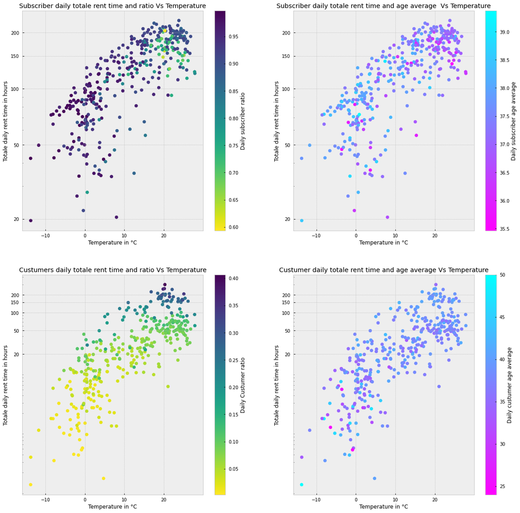

```python
plt.style.use(style_list[2])
ticks=[20,50,100,150, 200]
total_rent_time=(table_type['total_rent_time_s']+table_type['total_rent_time_c'])/3600
fig, ax = subplots(2,2, figsize=(20,20))

#Plotting Subscriber daily totale rent time and ratio Vs Temperature
Subscriber_plt=ax[0,0].scatter( c=table_type['subscriber_ratio'], x=table_type['temperature'], y=table_type['total_rent_time_s']/3600, cmap='viridis_r')
ax[0,0].set_ylabel("Totale daily rent time in hours")
ax[0,0].set_title("Subscriber daily totale rent time and ratio Vs Temperature")
ax[0,0].set_xlabel("Temperature in °C")
ax[0,0].set_yscale('log')
ax[0,0].set_yticks(ticks)
ax[0,0].set_yticklabels(ticks)
cbar=fig.colorbar(Subscriber_plt, ax=ax[0,0])
cbar.set_label('Daily subscriber ratio', rotation=90)


#Plotting Subscriber daily totale rent time and age average  Vs Temperature
Subscriber_plt=ax[0,1].scatter( c=table_type['age_avg_s'], x=table_type['temperature'], y=table_type['total_rent_time_s']/3600, cmap='cool_r')
ax[0,1].set_ylabel("Totale daily rent time in hours")
ax[0,1].set_title("Subscriber daily totale rent time and age average  Vs Temperature")
ax[0,1].set_xlabel("Temperature in °C")
ax[0,1].set_yscale('log')
ax[0,1].set_yticks(ticks)
ax[0,1].set_yticklabels(ticks)
cbar=fig.colorbar(Subscriber_plt, ax=ax[0,1])
cbar.set_label('Daily subscriber age average', rotation=90)

#Plotting Custumers daily totale rent time and ratio Vs Temperature
Custumer_plt=ax[1,0].scatter( c=table_type['custumer_ratio'], x=table_type['temperature'], y=table_type['total_rent_time_c']/3600, cmap='viridis_r')
ax[1,0].set_ylabel("Totale daily rent time in hours")
ax[1,0].set_title("Custumers daily totale rent time and ratio Vs Temperature")
ax[1,0].set_xlabel("Temperature in °C")
ax[1,0].set_yscale('log')
ax[1,0].set_yticks(ticks)
ax[1,0].set_yticklabels(ticks)
cbar=fig.colorbar(Custumer_plt, ax=ax[1,0])
cbar.set_label('Daily Custumer ratio', rotation=90)

#Plotting Custumer daily totale rent time and age average Vs Temperature
Custumer_plt=ax[1,1].scatter( c=table_type['age_avg_c'], x=table_type['temperature'], y=table_type['total_rent_time_c']/3600, cmap='cool_r')
ax[1,1].set_ylabel("Totale daily rent time in hours")
ax[1,1].set_title("Custumer daily totale rent time and age average Vs Temperature")
ax[1,1].set_xlabel("Temperature in °C")
ax[1,1].set_yscale('log')
ax[1,1].set_yticks(ticks)
ax[1,1].set_yticklabels(ticks)
cbar=fig.colorbar(Custumer_plt, ax=ax[1,1])
cbar.set_label('Daily custumer age average', rotation=90)



show()
```

By analyzing the plots above:

- for subscriber and custumers more the temperature increases more the total daily rent time increases
- More the temperature increases more the custumers ratio increases and the subscriber ratio decrease
- More the temperature increases more the subscriber age average decreases on the other hand more the temperature increases, more the custumers average age increases.

```python
day_dict={0:'Monday', 1:'Tuesday', 2:'Wednesday',
          3:'Thursday', 4:'Friday', 5:'Saturday', 6:'Sunday'}
table_gender['weekday']=pd.to_datetime(table_gender['date']).dt.dayofweek
table_gender.replace({"weekday": day_dict}, inplace=True)
table_gender.head()
```

|  | date | age_avg_f | age_avg_m | age_avg_u | humidity | precipitation | temperature | total_rent_time_f | total_rent_time_m | total_rent_time_u | ... | total_traveled_distance_m | total_traveled_distance_u | trip_count_f | trip_count_m | trip_count_u | wind_speed | female_ratio | male_ratio | unknown_ratio | weekday |
| --- | --- | --- | --- | --- | --- | --- | --- | --- | --- | --- | --- | --- | --- | --- | --- | --- | --- | --- | --- | --- | --- |
| 0 | 2019-01-01 | 37.313253 | 37.587248 | 49.673469 | 91.37 | 1.64 | 7.48 | 50461.0 | 163124.0 | 108923.0 | ... | 244.654372 | 43.022046 | 83.0 | 298.0 | 49.0 | 5.41 | 0.193023 | 0.693023 | 0.113953 | Tuesday |
| 1 | 2019-01-02 | 37.365079 | 38.192691 | 48.611111 | 81.38 | 0.07 | 0.25 | 70945.0 | 234835.0 | 31789.0 | ... | 570.564739 | 28.152072 | 189.0 | 602.0 | 36.0 | 2.32 | 0.228537 | 0.727932 | 0.043531 | Wednesday |
| 2 | 2019-01-03 | 36.372881 | 38.334835 | 47.000000 | 89.86 | 0.29 | 2.20 | 71754.0 | 261402.0 | 6800.0 | ... | 648.940202 | 8.107255 | 177.0 | 666.0 | 16.0 | 3.04 | 0.206054 | 0.775320 | 0.018626 | Thursday |
| 3 | 2019-01-04 | 36.854054 | 37.856094 | 46.121212 | 94.72 | 0.67 | 1.51 | 76057.0 | 260496.0 | 28991.0 | ... | 619.175897 | 30.985349 | 185.0 | 681.0 | 33.0 | 2.84 | 0.205784 | 0.757508 | 0.036707 | Friday |
| 4 | 2019-01-05 | 35.702381 | 37.571429 | 42.000000 | 97.01 | 19.88 | 4.05 | 31423.0 | 85288.0 | 11477.0 | ... | 212.639560 | 11.297539 | 84.0 | 210.0 | 14.0 | 3.90 | 0.272727 | 0.681818 | 0.045455 | Saturday |

5 rows × 21 columns

```python
table_gender['day_type']=table_gender['weekday'].apply(lambda x: 'Week-day' if x in ['Monday', 'Tuesday','Wednesday', 'Thursday', 'Friday'] else 'Week-end')
```

[output not shown]

5 rows × 22 columns

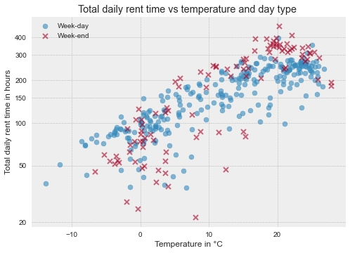

```python
total_rent_time=table_gender['total_rent_time_f']+table_gender['total_rent_time_m']+table_gender['total_rent_time_u']

day_markers = [['Week-day', 'o'],
               ['Week-end', 'x']]
ticks=[20,50,100,150, 200,300,400]
for day, marker in day_markers:
    table_day = table_gender[table_gender['day_type'] == day]
    total_rent_time=(table_day['total_rent_time_f']+table_day['total_rent_time_m']+table_day['total_rent_time_u'])/3600
    plt.scatter( x = table_day['temperature'], y = total_rent_time  , marker = marker, alpha=0.6)
    plt.yscale('log')
    plt.yticks(ticks,ticks)
    plt.title('Total daily rent time vs temperature and day type ')
    plt.xlabel('Temperature in °C')
    plt.ylabel('Total daily rent time in hours')

plt.legend(['Week-day','Week-end'])
```

From this graph we can see:

- For low temperatures (between -10 and 5 °C) the total rent time is higher in the week-days
- For high temperatures (higher than 5 °C) the total rent time is higher during the weekends

### Talk about some of the relationships you observed in this part of the investigation. Were there features that strengthened each other in terms of looking at your feature(s) of interest?

- The temperature has a remarkable influence on the ratio of females the higher the temperature, the more we observe the ratio of females which increases in parallel with the increase in the total daily rent time.
- Thus the temperature influences the average age of users: the more the temperature increases, the more the total daily rent time increases but the more the average age of users decreases.
- More the temperature increases more the custumers ratio increases.

### Were there any interesting or surprising interactions between features?

- For the average age of subscriber and custumers we observed a contradictory variation in relation to the temperature, More the temperature increases more the subscriber age average decreases and more the custumers average age increases.
- For temperatures below 5 ° C the total daily rent time is slightly higher than the weekend compared to the weekend, conversely when the temperature exceeds 5 ° C the total daily rent time for weekends remarkably exceeds that of week-day.